# Anxiety Support App: Marketing Audience Identification - Analysis Report

Paulo Araya Santiago

February 7th, 2025

```r
knitr::opts_chunk$set(echo = TRUE)

library(tidyverse)
library(skimr)
library(here)
library(janitor)
library(patchwork)
library(knitr)

# Define output file path
project_root <- here()
data_folder <- file.path(project_root, "data")
output_folder <- file.path(project_root, "output")
plots_folder <- file.path(output_folder, "plots")

data_file_path <- file.path(data_folder, "anxiety_attack_dataset.csv")

# --- Function for Lifestyle vs. Severity Plots ---
plot_lifestyle_vs_severity <- function(data, lifestyle_var) {
    ggplot(data, aes(x = .data[[lifestyle_var]], y = severity_of_anxiety_attack_1_10)) +
    geom_point(alpha = 0.3) +
    geom_smooth(method = "lm", se = FALSE) +
    labs(title = paste("Anxiety Severity vs.", lifestyle_var),
         x = lifestyle_var,
         y = "Severity of Anxiety Attack (1-10)")
}

# --- Function for Categorical Variable Comparison Plots ---
plot_categorical_comparison <- function(data, var_name) {
     ggplot(data, aes(x = factor(severity_of_anxiety_attack_1_10), fill = .data[[var_name]] )) +
        geom_bar(position = "fill") +
        labs(title = paste("Proportion of", var_name, "by Anxiety Severity"),
        x = "Severity of Anxiety Attack (1-10)",
        y = "Proportion",
        fill = var_name) +
        scale_y_continuous(labels = scales::percent)
}
```

## 1. Introduction

This report documents the complete data analysis process for the “Calm Button” application marketing audience identification project. This project is a **fictional case study** developed as part of the Google Data Analytics Certification. The goal is to identify and characterize high-potential target audiences for the “Calm Button” app, which is presented as a hypothetical mobile application designed to provide immediate, discreet anxiety relief, particularly in workplace settings. We aim to move beyond broad demographic targeting and pinpoint specific segments most likely to benefit from the app’s features.

While this is a simulated scenario, the data analysis process and techniques used are real and reflect industry best practices. The insights derived from this analysis, although based on a synthetic dataset, are intended to demonstrate how data-driven decision-making can inform marketing strategies.

Our analysis followed the established data analysis process: Ask, Prepare, Process, Analyze, Share, and Act. This notebook provides a comprehensive and reproducible record of all steps, from defining the business problem and research questions to data preparation, analysis, and key findings.

### 1.1. Guiding SMART Questions

To ensure our analysis was focused and relevant, we developed the following SMART (Specific, Measurable, Action-oriented, Relevant, and Time-bound) questions to guide our investigation:

- **High-Stress & Lifestyle Segments:**
  1. **Stress & Severity:** Among individuals reporting high stress levels (stress_level_1_10 >= 8), what is the distribution of `severity_of_anxiety_attack_1_10`? What percentage report severe anxiety attacks (>= 8)?
  2. **Lifestyle & High Stress/Severity:** Within the high-stress, high-severity group (defined in Q1), what are the average values and distributions of key lifestyle factors: `sleep_hours`, `physical_activity_hrs_week`, `caffeine_intake_mg_day`, `alcohol_consumption_drinks_week`, and `diet_quality_1_10`? How do these compare to the overall dataset averages?
  3. **Untreated Need:** What proportion of individuals with high stress and high anxiety severity (defined in Q1) report no therapy (`therapy_sessions_per_month` = 0) and no medication use (`medication` = “No”)? This identifies a potential “untreated” segment.
  4. **Age & High Stress/Severity:** Within the high-stress, high-severity group, are there significant differences in anxiety severity, lifestyle factors, or treatment usage across different age groups (e.g., 18-29, 30-44, 45-64)?
  5. **Physiological Response:** What is the average `heart_rate_bpm_during_attack` and the average `breathing_rate_breaths_min` in people with a `severity_of_anxiety_attack_1_10` of 8 or higher, versus people with a `severity_of_anxiety_attack_1_10` of 3 or lower?
  6. **Therapy Usage and Severity:** Among those who report attending therapy (`therapy_sessions_per_month` > 0) , what is the median reported `severity_of_anxiety_attack_1_10`?
- **Behavioral & Contextual Analysis:**
  7. **Lifestyle Correlations:** Across the *entire* dataset, what are the correlations between the key lifestyle factors (`sleep_hours`, `physical_activity_hrs_week`, `caffeine_intake_mg_day`, `alcohol_consumption_drinks_week`, `diet_quality_1_10`) and `severity_of_anxiety_attack_1_10`? Are these correlations statistically significant?
  8. **Smoking, Family History, Dizziness, Life Events:** What proportion of individuals with high anxiety severity (>= 8) report: smoking, a family history of anxiety, dizziness during anxiety attacks and a recent major life event. How do these proportions compare to those with low anxiety severity (< 4)?
  9. **Messaging & Value Proposition:** Based on the identified needs, behaviors, and pain points of the target segments, how should the “Calm Button” app be positioned in marketing messaging to best resonate with their specific workplace anxiety challenges and highlight its value proposition (discretion, instant access, haptic feedback, privacy)?

These questions provide a clear framework for our analysis and ensure that our findings are directly relevant to the business objectives.

## 2. Project Setup and Data Acquisition

The necessary R packages (`tidyverse`, `skimr`, `here`, `janitor`, `patchwork`, `knitr`) were loaded, and project paths were defined using the `here` package for portability. The dataset, `anxiety_attack_dataset.csv`, was imported into R.

## 3. Data Preparation (Prepare Phase) - Summary

```r
# --- Data Import and Initial Cleaning (from Prepare phase) ---
anxiety_data_raw <- read_csv(data_file_path)
anxiety_data_clean_names <- janitor::clean_names(anxiety_data_raw)

# --- Function for Categorical Variable Visualization ---
plot_categorical <- function(data, var_name) {
  # Create bar plot
  ggplot(data, aes(x = .data[[var_name]])) +
    geom_bar() +
    labs(title = paste("Distribution of", var_name),
         x = var_name,
         y = "Count") +
    theme(axis.text.x = element_text(angle = 45, hjust = 1))
}

# --- Function for Numeric Variable Visualization ---
plot_numeric <- function(data, var_name) {
  # Create histogram + boxplot
  list(histogram = ggplot(data, aes(x = .data[[var_name]])) +
                        geom_histogram(bins = 30) +
                        labs(title = paste("Distribution of", var_name),
                             x = var_name,
                             y = "Count"),
       boxplot = ggplot(data, aes(y = .data[[var_name]])) +
                    geom_boxplot() +
                    labs(title = paste("Boxplot of", var_name),
                         y = var_name)
       )
}


categorical_vars <- c("gender", "occupation", "smoking", "family_history_of_anxiety",
                     "dizziness", "medication", "recent_major_life_event")
numeric_vars <- c("age", "sleep_hours", "physical_activity_hrs_week",
                 "caffeine_intake_mg_day", "alcohol_consumption_drinks_week",
                 "stress_level_1_10", "heart_rate_bpm_during_attack",
                 "breathing_rate_breaths_min", "sweating_level_1_5",
                 "therapy_sessions_per_month", "diet_quality_1_10",
                 "severity_of_anxiety_attack_1_10")
```

**Key Observations from Prepare Phase:**

- The dataset is complete and clean, with no missing values or duplicates.
- Occupations are relatively evenly distributed, suggesting that occupation alone may not be a strong differentiator for anxiety levels.
- Several numeric variables (`sleep_hours`, `physical_activity_hrs_week`, `caffeine_intake_mg_day`, `alcohol_consumption_drinks_week`, `heart_rate_bpm_during_attack`, `breathing_rate_breaths_min`) exhibited potential outliers, which would require further investigation.

## 4. Data Processing

```r
# --- Data Processing ---

# Data Type Conversion
anxiety_data_processed <- anxiety_data_clean_names %>%
  mutate(across(all_of(categorical_vars), as.factor))

# Outlier Investigation (all outliers were kept after contextual review)

# Variable Creation
anxiety_data_processed <- anxiety_data_processed %>%
  mutate(high_stress = ifelse(stress_level_1_10 >= 8, 1, 0),
         high_severity = ifelse(severity_of_anxiety_attack_1_10 >= 8, 1, 0),
         untreated = ifelse(high_stress == 1 & high_severity == 1 & therapy_sessions_per_month == 0 & medication == "No", 1, 0),
         low_sleep = ifelse(sleep_hours < 7, 1, 0),
         high_alcohol = ifelse( (gender == "Female" & alcohol_consumption_drinks_week >= 8) |
                                     (gender == "Male"   & alcohol_consumption_drinks_week >= 15) |
                                     (gender == "Other" & alcohol_consumption_drinks_week >= 15)
                                   , 1, 0),
        high_caffeine = ifelse(caffeine_intake_mg_day > 400, 1, 0),
        age_group = cut(age, breaks = c(18, 30, 45, 65), labels = c("18-29", "30-44", "45-64"), include.lowest = TRUE))

#Final Verification
# Check for NA's again in the new variables
missing_values_processed <- colSums(is.na(anxiety_data_processed))
# Check for Duplicates again
duplicates_processed <- anxiety_data_processed %>%
  duplicated() %>%
  sum()
```

The Process phase involved the following data cleaning and transformation steps:

1. **Data Type Conversion:** All character variables identified as categorical in the Prepare phase were converted to factors in R. This ensures correct handling in subsequent statistical analyses and visualizations.
2. **Outlier Investigation:** Potential outliers identified in the Prepare phase were examined in context. After careful consideration, all potential outlier values were *retained*, as they were deemed plausible within the context of the dataset. This decision was documented.
3. **Variable Creation:** Six new binary indicator variables were created to facilitate analysis and segmentation:
   - `high_stress`: Indicates high reported stress levels (>= 8).
   - `high_severity`: Indicates high reported anxiety attack severity (>= 8).
   - `untreated`: Indicates individuals who are both high-stress and high-severity and are *not* receiving therapy or medication.
   - `low_sleep`: Indicates individuals reporting less than 7 hours of sleep.
   - `high_alcohol`: Indicates individuals exceeding recommended weekly alcohol consumption limits.
   - `high_caffeine`: Indicates individuals consuming more than 400mg of caffeine daily.
   - `age_group`: Indicates individuals age group. These variables are directly aligned with the refined SMART questions and allow for targeted analysis of key subgroups.

## 5. Data Analysis (Analyze Phase)

This section presents the analysis performed to address the SMART questions, using the processed data (`anxiety_data_processed`).

### 5.1. Descriptive Statistics (Targeted Groups)

We began by calculating descriptive statistics for the entire dataset and for key subgroups defined by our indicator variables. This provides an overview of the data distribution and allows for comparisons between groups.

```r
# --- Overall Descriptive Statistics ---
cat("\nOverall Descriptive Statistics:\n")
```

```
Overall Descriptive Statistics:
```

```r
print(kable(skim(anxiety_data_processed), format = "markdown"))
```

| skim_type | skim_variable | n_missing | complete_rate | factor.ordered | factor.n_unique | factor.top_counts | numeric.mean | numeric.sd | numeric.p0 | numeric.p25 | numeric.p50 | numeric.p75 | numeric.p100 | numeric.hist |
| --- | --- | --- | --- | --- | --- | --- | --- | --- | --- | --- | --- | --- | --- | --- |
| factor | gender | 0 | 1 | FALSE | 3 | Fem: 5809, Mal: 5723, Oth: 468 | NA | NA | NA | NA | NA | NA | NA | NA |
| factor | occupation | 0 | 1 | FALSE | 6 | Une: 2139, Doc: 2004, Tea: 1980, Oth: 1971 | NA | NA | NA | NA | NA | NA | NA | NA |
| factor | smoking | 0 | 1 | FALSE | 2 | No: 8417, Yes: 3583 | NA | NA | NA | NA | NA | NA | NA | NA |
| factor | family_history_of_anxiety | 0 | 1 | FALSE | 2 | No: 7179, Yes: 4821 | NA | NA | NA | NA | NA | NA | NA | NA |
| factor | dizziness | 0 | 1 | FALSE | 2 | No: 8406, Yes: 3594 | NA | NA | NA | NA | NA | NA | NA | NA |
| factor | medication | 0 | 1 | FALSE | 2 | No: 9605, Yes: 2395 | NA | NA | NA | NA | NA | NA | NA | NA |
| factor | recent_major_life_event | 0 | 1 | FALSE | 2 | No: 9054, Yes: 2946 | NA | NA | NA | NA | NA | NA | NA | NA |
| factor | age_group | 0 | 1 | FALSE | 3 | 45-: 4792, 30-: 3922, 18-: 3286 | NA | NA | NA | NA | NA | NA | NA | NA |
| numeric | id | 0 | 1 | NA | NA | NA | 6000.5000000 | 3464.2459497 | 1 | 3000.75 | 6000.5 | 9000.250 | 12000 | ▇▇▇▇▇ |
| numeric | age | 0 | 1 | NA | NA | NA | 40.9667500 | 13.4732799 | 18 | 29.00 | 41.0 | 53.000 | 64 | ▇▇▇▇▇ |
| numeric | sleep_hours | 0 | 1 | NA | NA | NA | 6.4826500 | 2.0148852 | 3 | 4.80 | 6.5 | 8.200 | 10 | ▇▇▇▇▇ |
| numeric | physical_activity_hrs_week | 0 | 1 | NA | NA | NA | 5.0308917 | 2.8890002 | 0 | 2.50 | 5.0 | 7.525 | 10 | ▇▇▇▇▇ |
| numeric | caffeine_intake_mg_day | 0 | 1 | NA | NA | NA | 246.6960833 | 144.4870713 | 0 | 122.00 | 244.0 | 371.000 | 499 | ▇▇▇▇▇ |
| numeric | alcohol_consumption_drinks_week | 0 | 1 | NA | NA | NA | 9.4928333 | 5.7693635 | 0 | 5.00 | 9.0 | 15.000 | 19 | ▇▇▇▇▇ |
| numeric | stress_level_1_10 | 0 | 1 | NA | NA | NA | 5.4622500 | 2.8972011 | 1 | 3.00 | 5.0 | 8.000 | 10 | ▇▇▇▇▇ |
| numeric | heart_rate_bpm_during_attack | 0 | 1 | NA | NA | NA | 119.3985000 | 34.8067114 | 60 | 89.00 | 119.0 | 149.000 | 179 | ▇▇▇▇▇ |
| numeric | breathing_rate_breaths_min | 0 | 1 | NA | NA | NA | 25.4623333 | 8.0906862 | 12 | 18.00 | 25.0 | 32.000 | 39 | ▇▆▇▆▇ |
| numeric | sweating_level_1_5 | 0 | 1 | NA | NA | NA | 2.9874167 | 1.4144817 | 1 | 2.00 | 3.0 | 4.000 | 5 | ▇▇▇▇▇ |
| numeric | therapy_sessions_per_month | 0 | 1 | NA | NA | NA | 4.5184167 | 2.8660098 | 0 | 2.00 | 5.0 | 7.000 | 9 | ▇▇▇▇▇ |
| numeric | diet_quality_1_10 | 0 | 1 | NA | NA | NA | 5.4973333 | 2.8675794 | 1 | 3.00 | 5.0 | 8.000 | 10 | ▇▇▇▇▇ |
| numeric | severity_of_anxiety_attack_1_10 | 0 | 1 | NA | NA | NA | 5.5075833 | 2.8586635 | 1 | 3.00 | 6.0 | 8.000 | 10 | ▇▇▇▇▇ |
| numeric | high_stress | 0 | 1 | NA | NA | NA | 0.2951667 | 0.4561367 | 0 | 0.00 | 0.0 | 1.000 | 1 | ▇▁▁▁▃ |
| numeric | high_severity | 0 | 1 | NA | NA | NA | 0.2970833 | 0.4569926 | 0 | 0.00 | 0.0 | 1.000 | 1 | ▇▁▁▁▃ |
| numeric | untreated | 0 | 1 | NA | NA | NA | 0.0057500 | 0.0756136 | 0 | 0.00 | 0.0 | 0.000 | 1 | ▇▁▁▁▁ |
| numeric | low_sleep | 0 | 1 | NA | NA | NA | 0.5736667 | 0.4945641 | 0 | 0.00 | 1.0 | 1.000 | 1 | ▆▁▁▁▇ |
| numeric | high_alcohol | 0 | 1 | NA | NA | NA | 0.4219167 | 0.4938859 | 0 | 0.00 | 0.0 | 1.000 | 1 | ▇▁▁▁▆ |
| numeric | high_caffeine | 0 | 1 | NA | NA | NA | 0.1913333 | 0.3933672 | 0 | 0.00 | 0.0 | 0.000 | 1 | ▇▁▁▁▂ |

```r
# --- High Stress Group (stress_level_1_10 >= 8) ---
cat("\nHigh Stress Group (stress_level_1_10 >= 8):\n")
```

```
High Stress Group (stress_level_1_10 >= 8):
```

```r
high_stress_skim <- anxiety_data_processed %>%
  filter(high_stress == 1) %>%
  skim()
print(kable(high_stress_skim, format = "markdown"))
```

| skim_type | skim_variable | n_missing | complete_rate | factor.ordered | factor.n_unique | factor.top_counts | numeric.mean | numeric.sd | numeric.p0 | numeric.p25 | numeric.p50 | numeric.p75 | numeric.p100 | numeric.hist |
| --- | --- | --- | --- | --- | --- | --- | --- | --- | --- | --- | --- | --- | --- | --- |
| factor | gender | 0 | 1 | FALSE | 3 | Fem: 1714, Mal: 1684, Oth: 144 | NA | NA | NA | NA | NA | NA | NA | NA |
| factor | occupation | 0 | 1 | FALSE | 6 | Une: 643, Doc: 618, Oth: 593, Tea: 583 | NA | NA | NA | NA | NA | NA | NA | NA |
| factor | smoking | 0 | 1 | FALSE | 2 | No: 2498, Yes: 1044 | NA | NA | NA | NA | NA | NA | NA | NA |
| factor | family_history_of_anxiety | 0 | 1 | FALSE | 2 | No: 2167, Yes: 1375 | NA | NA | NA | NA | NA | NA | NA | NA |
| factor | dizziness | 0 | 1 | FALSE | 2 | No: 2510, Yes: 1032 | NA | NA | NA | NA | NA | NA | NA | NA |
| factor | medication | 0 | 1 | FALSE | 2 | No: 2845, Yes: 697 | NA | NA | NA | NA | NA | NA | NA | NA |
| factor | recent_major_life_event | 0 | 1 | FALSE | 2 | No: 2653, Yes: 889 | NA | NA | NA | NA | NA | NA | NA | NA |
| factor | age_group | 0 | 1 | FALSE | 3 | 45-: 1476, 30-: 1125, 18-: 941 | NA | NA | NA | NA | NA | NA | NA | NA |
| numeric | id | 0 | 1 | NA | NA | NA | 5983.1894410 | 3465.0240856 | 21 | 2960.25 | 6028.0 | 8894.75 | 11999 | ▇▇▇▇▇ |
| numeric | age | 0 | 1 | NA | NA | NA | 41.4212309 | 13.4551408 | 18 | 30.00 | 42.0 | 53.00 | 64 | ▇▇▇▇▇ |
| numeric | sleep_hours | 0 | 1 | NA | NA | NA | 6.4819029 | 2.0236801 | 3 | 4.70 | 6.5 | 8.20 | 10 | ▇▇▇▇▇ |
| numeric | physical_activity_hrs_week | 0 | 1 | NA | NA | NA | 5.0207228 | 2.8872153 | 0 | 2.60 | 5.0 | 7.50 | 10 | ▇▇▇▇▇ |
| numeric | caffeine_intake_mg_day | 0 | 1 | NA | NA | NA | 250.9618859 | 145.5021705 | 0 | 126.00 | 249.0 | 376.00 | 499 | ▇▇▇▇▇ |
| numeric | alcohol_consumption_drinks_week | 0 | 1 | NA | NA | NA | 9.5118577 | 5.7096509 | 0 | 5.00 | 9.0 | 14.00 | 19 | ▇▇▇▇▇ |
| numeric | stress_level_1_10 | 0 | 1 | NA | NA | NA | 9.0271033 | 0.8145455 | 8 | 8.00 | 9.0 | 10.00 | 10 | ▇▁▇▁▇ |
| numeric | heart_rate_bpm_during_attack | 0 | 1 | NA | NA | NA | 118.8740824 | 34.6482622 | 60 | 89.00 | 119.0 | 150.00 | 179 | ▇▇▇▇▇ |
| numeric | breathing_rate_breaths_min | 0 | 1 | NA | NA | NA | 25.4271598 | 8.0480888 | 12 | 19.00 | 25.0 | 32.00 | 39 | ▇▇▇▆▇ |
| numeric | sweating_level_1_5 | 0 | 1 | NA | NA | NA | 2.9664032 | 1.4169070 | 1 | 2.00 | 3.0 | 4.00 | 5 | ▇▇▇▇▇ |
| numeric | therapy_sessions_per_month | 0 | 1 | NA | NA | NA | 4.5982496 | 2.8629285 | 0 | 2.00 | 5.0 | 7.00 | 9 | ▇▇▇▇▇ |
| numeric | diet_quality_1_10 | 0 | 1 | NA | NA | NA | 5.5143986 | 2.8628030 | 1 | 3.00 | 6.0 | 8.00 | 10 | ▇▇▇▇▇ |
| numeric | severity_of_anxiety_attack_1_10 | 0 | 1 | NA | NA | NA | 5.5203275 | 2.8677937 | 1 | 3.00 | 5.0 | 8.00 | 10 | ▇▇▇▇▇ |
| numeric | high_stress | 0 | 1 | NA | NA | NA | 1.0000000 | 0.0000000 | 1 | 1.00 | 1.0 | 1.00 | 1 | ▁▁▇▁▁ |
| numeric | high_severity | 0 | 1 | NA | NA | NA | 0.3043478 | 0.4601956 | 0 | 0.00 | 0.0 | 1.00 | 1 | ▇▁▁▁▃ |
| numeric | untreated | 0 | 1 | NA | NA | NA | 0.0194805 | 0.1382260 | 0 | 0.00 | 0.0 | 0.00 | 1 | ▇▁▁▁▁ |
| numeric | low_sleep | 0 | 1 | NA | NA | NA | 0.5705816 | 0.4950631 | 0 | 0.00 | 1.0 | 1.00 | 1 | ▆▁▁▁▇ |
| numeric | high_alcohol | 0 | 1 | NA | NA | NA | 0.4223602 | 0.4940050 | 0 | 0.00 | 0.0 | 1.00 | 1 | ▇▁▁▁▆ |
| numeric | high_caffeine | 0 | 1 | NA | NA | NA | 0.2027103 | 0.4020752 | 0 | 0.00 | 0.0 | 0.00 | 1 | ▇▁▁▁▂ |

```r
# --- High Severity Group (severity_of_anxiety_attack_1_10 >= 8) ---
cat("\nHigh Severity Group (severity_of_anxiety_attack_1_10 >= 8):\n")
```

```
High Severity Group (severity_of_anxiety_attack_1_10 >= 8):
```

```r
high_severity_skim <- anxiety_data_processed %>%
  filter(high_severity == 1) %>%
  skim()
print(kable(high_severity_skim, format = "markdown"))
```

| skim_type | skim_variable | n_missing | complete_rate | factor.ordered | factor.n_unique | factor.top_counts | numeric.mean | numeric.sd | numeric.p0 | numeric.p25 | numeric.p50 | numeric.p75 | numeric.p100 | numeric.hist |
| --- | --- | --- | --- | --- | --- | --- | --- | --- | --- | --- | --- | --- | --- | --- |
| factor | gender | 0 | 1 | FALSE | 3 | Fem: 1720, Mal: 1707, Oth: 138 | NA | NA | NA | NA | NA | NA | NA | NA |
| factor | occupation | 0 | 1 | FALSE | 6 | Une: 650, Oth: 595, Tea: 587, Eng: 584 | NA | NA | NA | NA | NA | NA | NA | NA |
| factor | smoking | 0 | 1 | FALSE | 2 | No: 2530, Yes: 1035 | NA | NA | NA | NA | NA | NA | NA | NA |
| factor | family_history_of_anxiety | 0 | 1 | FALSE | 2 | No: 2105, Yes: 1460 | NA | NA | NA | NA | NA | NA | NA | NA |
| factor | dizziness | 0 | 1 | FALSE | 2 | No: 2448, Yes: 1117 | NA | NA | NA | NA | NA | NA | NA | NA |
| factor | medication | 0 | 1 | FALSE | 2 | No: 2862, Yes: 703 | NA | NA | NA | NA | NA | NA | NA | NA |
| factor | recent_major_life_event | 0 | 1 | FALSE | 2 | No: 2711, Yes: 854 | NA | NA | NA | NA | NA | NA | NA | NA |
| factor | age_group | 0 | 1 | FALSE | 3 | 45-: 1418, 30-: 1136, 18-: 1011 | NA | NA | NA | NA | NA | NA | NA | NA |
| numeric | id | 0 | 1 | NA | NA | NA | 5941.5506311 | 3468.7468716 | 1 | 2921.0 | 5874.0 | 8941.0 | 11998 | ▇▇▇▇▇ |
| numeric | age | 0 | 1 | NA | NA | NA | 40.7542777 | 13.5025743 | 18 | 29.0 | 41.0 | 52.0 | 64 | ▇▇▇▇▇ |
| numeric | sleep_hours | 0 | 1 | NA | NA | NA | 6.4638710 | 2.0430583 | 3 | 4.7 | 6.4 | 8.2 | 10 | ▇▇▇▇▇ |
| numeric | physical_activity_hrs_week | 0 | 1 | NA | NA | NA | 5.1044320 | 2.8752890 | 0 | 2.6 | 5.1 | 7.7 | 10 | ▇▇▇▇▇ |
| numeric | caffeine_intake_mg_day | 0 | 1 | NA | NA | NA | 247.4659187 | 144.4413647 | 0 | 122.0 | 246.0 | 371.0 | 499 | ▇▇▇▇▇ |
| numeric | alcohol_consumption_drinks_week | 0 | 1 | NA | NA | NA | 9.4737728 | 5.7484883 | 0 | 5.0 | 9.0 | 14.0 | 19 | ▇▇▇▇▇ |
| numeric | stress_level_1_10 | 0 | 1 | NA | NA | NA | 5.4995792 | 2.9142847 | 1 | 3.0 | 6.0 | 8.0 | 10 | ▇▇▇▇▇ |
| numeric | heart_rate_bpm_during_attack | 0 | 1 | NA | NA | NA | 119.2244039 | 35.1393429 | 60 | 88.0 | 119.0 | 150.0 | 179 | ▇▇▇▇▇ |
| numeric | breathing_rate_breaths_min | 0 | 1 | NA | NA | NA | 25.5481066 | 8.1092256 | 12 | 19.0 | 26.0 | 33.0 | 39 | ▇▆▇▆▇ |
| numeric | sweating_level_1_5 | 0 | 1 | NA | NA | NA | 3.0067321 | 1.4138007 | 1 | 2.0 | 3.0 | 4.0 | 5 | ▇▇▇▇▇ |
| numeric | therapy_sessions_per_month | 0 | 1 | NA | NA | NA | 4.4796634 | 2.8818765 | 0 | 2.0 | 4.0 | 7.0 | 9 | ▇▇▇▇▇ |
| numeric | diet_quality_1_10 | 0 | 1 | NA | NA | NA | 5.4712482 | 2.8523477 | 1 | 3.0 | 5.0 | 8.0 | 10 | ▇▇▇▇▇ |
| numeric | severity_of_anxiety_attack_1_10 | 0 | 1 | NA | NA | NA | 9.0000000 | 0.8161529 | 8 | 8.0 | 9.0 | 10.0 | 10 | ▇▁▇▁▇ |
| numeric | high_stress | 0 | 1 | NA | NA | NA | 0.3023843 | 0.4593552 | 0 | 0.0 | 0.0 | 1.0 | 1 | ▇▁▁▁▃ |
| numeric | high_severity | 0 | 1 | NA | NA | NA | 1.0000000 | 0.0000000 | 1 | 1.0 | 1.0 | 1.0 | 1 | ▁▁▇▁▁ |
| numeric | untreated | 0 | 1 | NA | NA | NA | 0.0193548 | 0.1377881 | 0 | 0.0 | 0.0 | 0.0 | 1 | ▇▁▁▁▁ |
| numeric | low_sleep | 0 | 1 | NA | NA | NA | 0.5733520 | 0.4946596 | 0 | 0.0 | 1.0 | 1.0 | 1 | ▆▁▁▁▇ |
| numeric | high_alcohol | 0 | 1 | NA | NA | NA | 0.4185133 | 0.4933844 | 0 | 0.0 | 0.0 | 1.0 | 1 | ▇▁▁▁▆ |
| numeric | high_caffeine | 0 | 1 | NA | NA | NA | 0.1921459 | 0.3940424 | 0 | 0.0 | 0.0 | 0.0 | 1 | ▇▁▁▁▂ |

```r
# --- Untreated Group (high_stress, high_severity, no therapy/medication) ---
cat("\nUntreated Group (High Stress, High Severity, No Therapy/Medication):\n")
```

```
Untreated Group (High Stress, High Severity, No Therapy/Medication):
```

```r
untreated_skim <- anxiety_data_processed %>%
  filter(untreated == 1) %>%
  skim()
print(kable(untreated_skim, format = "markdown"))
```

| skim_type | skim_variable | n_missing | complete_rate | factor.ordered | factor.n_unique | factor.top_counts | numeric.mean | numeric.sd | numeric.p0 | numeric.p25 | numeric.p50 | numeric.p75 | numeric.p100 | numeric.hist |
| --- | --- | --- | --- | --- | --- | --- | --- | --- | --- | --- | --- | --- | --- | --- |
| factor | gender | 0 | 1 | FALSE | 3 | Mal: 37, Fem: 31, Oth: 1 | NA | NA | NA | NA | NA | NA | NA | NA |
| factor | occupation | 0 | 1 | FALSE | 6 | Doc: 14, Eng: 13, Oth: 13, Une: 12 | NA | NA | NA | NA | NA | NA | NA | NA |
| factor | smoking | 0 | 1 | FALSE | 2 | No: 47, Yes: 22 | NA | NA | NA | NA | NA | NA | NA | NA |
| factor | family_history_of_anxiety | 0 | 1 | FALSE | 2 | No: 39, Yes: 30 | NA | NA | NA | NA | NA | NA | NA | NA |
| factor | dizziness | 0 | 1 | FALSE | 2 | No: 47, Yes: 22 | NA | NA | NA | NA | NA | NA | NA | NA |
| factor | medication | 0 | 1 | FALSE | 1 | No: 69, Yes: 0 | NA | NA | NA | NA | NA | NA | NA | NA |
| factor | recent_major_life_event | 0 | 1 | FALSE | 2 | No: 53, Yes: 16 | NA | NA | NA | NA | NA | NA | NA | NA |
| factor | age_group | 0 | 1 | FALSE | 3 | 30-: 25, 45-: 25, 18-: 19 | NA | NA | NA | NA | NA | NA | NA | NA |
| numeric | id | 0 | 1 | NA | NA | NA | 5219.0289855 | 3847.4373479 | 63.0 | 1707.0 | 4542.0 | 9409.0 | 11872 | ▇▅▃▃▆ |
| numeric | age | 0 | 1 | NA | NA | NA | 39.6666667 | 12.6568589 | 18.0 | 30.0 | 40.0 | 50.0 | 64 | ▇▇▇▇▅ |
| numeric | sleep_hours | 0 | 1 | NA | NA | NA | 6.5478261 | 2.1423330 | 3.0 | 4.8 | 6.7 | 8.4 | 10 | ▇▆▅▇▇ |
| numeric | physical_activity_hrs_week | 0 | 1 | NA | NA | NA | 5.5652174 | 2.9555942 | 0.3 | 2.7 | 5.9 | 8.3 | 10 | ▅▅▇▆▇ |
| numeric | caffeine_intake_mg_day | 0 | 1 | NA | NA | NA | 257.5362319 | 149.7427775 | 1.0 | 149.0 | 254.0 | 377.0 | 495 | ▆▆▆▆▇ |
| numeric | alcohol_consumption_drinks_week | 0 | 1 | NA | NA | NA | 9.8985507 | 5.3030095 | 0.0 | 5.0 | 10.0 | 14.0 | 19 | ▃▆▇▃▇ |
| numeric | stress_level_1_10 | 0 | 1 | NA | NA | NA | 8.8985507 | 0.8427010 | 8.0 | 8.0 | 9.0 | 10.0 | 10 | ▇▁▆▁▆ |
| numeric | heart_rate_bpm_during_attack | 0 | 1 | NA | NA | NA | 109.1014493 | 33.2057512 | 61.0 | 79.0 | 107.0 | 135.0 | 175 | ▇▅▇▆▂ |
| numeric | breathing_rate_breaths_min | 0 | 1 | NA | NA | NA | 27.2463768 | 8.1842852 | 12.0 | 21.0 | 29.0 | 34.0 | 39 | ▅▃▅▆▇ |
| numeric | sweating_level_1_5 | 0 | 1 | NA | NA | NA | 3.0144928 | 1.4500786 | 1.0 | 2.0 | 3.0 | 4.0 | 5 | ▇▆▇▆▇ |
| numeric | therapy_sessions_per_month | 0 | 1 | NA | NA | NA | 0.0000000 | 0.0000000 | 0.0 | 0.0 | 0.0 | 0.0 | 0 | ▁▁▇▁▁ |
| numeric | diet_quality_1_10 | 0 | 1 | NA | NA | NA | 5.2028986 | 2.9234333 | 1.0 | 2.0 | 5.0 | 7.0 | 10 | ▇▅▇▆▅ |
| numeric | severity_of_anxiety_attack_1_10 | 0 | 1 | NA | NA | NA | 9.0000000 | 0.8401681 | 8.0 | 8.0 | 9.0 | 10.0 | 10 | ▇▁▇▁▇ |
| numeric | high_stress | 0 | 1 | NA | NA | NA | 1.0000000 | 0.0000000 | 1.0 | 1.0 | 1.0 | 1.0 | 1 | ▁▁▇▁▁ |
| numeric | high_severity | 0 | 1 | NA | NA | NA | 1.0000000 | 0.0000000 | 1.0 | 1.0 | 1.0 | 1.0 | 1 | ▁▁▇▁▁ |
| numeric | untreated | 0 | 1 | NA | NA | NA | 1.0000000 | 0.0000000 | 1.0 | 1.0 | 1.0 | 1.0 | 1 | ▁▁▇▁▁ |
| numeric | low_sleep | 0 | 1 | NA | NA | NA | 0.5362319 | 0.5023389 | 0.0 | 0.0 | 1.0 | 1.0 | 1 | ▇▁▁▁▇ |
| numeric | high_alcohol | 0 | 1 | NA | NA | NA | 0.4347826 | 0.4993602 | 0.0 | 0.0 | 0.0 | 1.0 | 1 | ▇▁▁▁▆ |
| numeric | high_caffeine | 0 | 1 | NA | NA | NA | 0.2463768 | 0.4340574 | 0.0 | 0.0 | 0.0 | 0.0 | 1 | ▇▁▁▁▂ |

```r
# --- Low Sleep Group (sleep_hours < 7) ---
cat("\nLow Sleep Group (sleep_hours < 7):\n")
```

```
Low Sleep Group (sleep_hours < 7):
```

```r
low_sleep_skim <- anxiety_data_processed %>%
  filter(low_sleep == 1) %>%
  skim()
print(kable(low_sleep_skim, format = "markdown"))
```

| skim_type | skim_variable | n_missing | complete_rate | factor.ordered | factor.n_unique | factor.top_counts | numeric.mean | numeric.sd | numeric.p0 | numeric.p25 | numeric.p50 | numeric.p75 | numeric.p100 | numeric.hist |
| --- | --- | --- | --- | --- | --- | --- | --- | --- | --- | --- | --- | --- | --- | --- |
| factor | gender | 0 | 1 | FALSE | 3 | Fem: 3324, Mal: 3281, Oth: 279 | NA | NA | NA | NA | NA | NA | NA | NA |
| factor | occupation | 0 | 1 | FALSE | 6 | Une: 1236, Doc: 1155, Stu: 1143, Oth: 1135 | NA | NA | NA | NA | NA | NA | NA | NA |
| factor | smoking | 0 | 1 | FALSE | 2 | No: 4894, Yes: 1990 | NA | NA | NA | NA | NA | NA | NA | NA |
| factor | family_history_of_anxiety | 0 | 1 | FALSE | 2 | No: 4095, Yes: 2789 | NA | NA | NA | NA | NA | NA | NA | NA |
| factor | dizziness | 0 | 1 | FALSE | 2 | No: 4805, Yes: 2079 | NA | NA | NA | NA | NA | NA | NA | NA |
| factor | medication | 0 | 1 | FALSE | 2 | No: 5515, Yes: 1369 | NA | NA | NA | NA | NA | NA | NA | NA |
| factor | recent_major_life_event | 0 | 1 | FALSE | 2 | No: 5194, Yes: 1690 | NA | NA | NA | NA | NA | NA | NA | NA |
| factor | age_group | 0 | 1 | FALSE | 3 | 45-: 2703, 30-: 2294, 18-: 1887 | NA | NA | NA | NA | NA | NA | NA | NA |
| numeric | id | 0 | 1 | NA | NA | NA | 6029.9456711 | 3450.6706995 | 2 | 3058.75 | 6044.5 | 9008.50 | 12000.0 | ▇▇▇▇▇ |
| numeric | age | 0 | 1 | NA | NA | NA | 40.8782684 | 13.3999377 | 18 | 29.00 | 41.0 | 52.00 | 64.0 | ▇▇▇▇▇ |
| numeric | sleep_hours | 0 | 1 | NA | NA | NA | 4.9948576 | 1.1452000 | 3 | 4.00 | 5.0 | 6.00 | 6.9 | ▇▇▇▇▇ |
| numeric | physical_activity_hrs_week | 0 | 1 | NA | NA | NA | 5.0198141 | 2.8583361 | 0 | 2.60 | 5.0 | 7.50 | 10.0 | ▇▇▇▇▇ |
| numeric | caffeine_intake_mg_day | 0 | 1 | NA | NA | NA | 246.2486926 | 144.6147327 | 0 | 120.00 | 244.0 | 372.00 | 499.0 | ▇▇▇▇▇ |
| numeric | alcohol_consumption_drinks_week | 0 | 1 | NA | NA | NA | 9.3999128 | 5.7901965 | 0 | 4.00 | 9.0 | 14.25 | 19.0 | ▇▇▇▇▇ |
| numeric | stress_level_1_10 | 0 | 1 | NA | NA | NA | 5.4402963 | 2.9002613 | 1 | 3.00 | 5.0 | 8.00 | 10.0 | ▇▇▇▇▇ |
| numeric | heart_rate_bpm_during_attack | 0 | 1 | NA | NA | NA | 119.9251888 | 34.6850391 | 60 | 90.00 | 120.0 | 150.00 | 179.0 | ▇▇▇▇▇ |
| numeric | breathing_rate_breaths_min | 0 | 1 | NA | NA | NA | 25.5261476 | 8.1236118 | 12 | 19.00 | 25.0 | 33.00 | 39.0 | ▇▇▇▆▇ |
| numeric | sweating_level_1_5 | 0 | 1 | NA | NA | NA | 2.9818420 | 1.4096207 | 1 | 2.00 | 3.0 | 4.00 | 5.0 | ▇▇▇▇▇ |
| numeric | therapy_sessions_per_month | 0 | 1 | NA | NA | NA | 4.5302150 | 2.8511607 | 0 | 2.00 | 5.0 | 7.00 | 9.0 | ▇▇▇▇▇ |
| numeric | diet_quality_1_10 | 0 | 1 | NA | NA | NA | 5.4841662 | 2.8586557 | 1 | 3.00 | 5.0 | 8.00 | 10.0 | ▇▇▇▇▇ |
| numeric | severity_of_anxiety_attack_1_10 | 0 | 1 | NA | NA | NA | 5.5017432 | 2.8589023 | 1 | 3.00 | 5.0 | 8.00 | 10.0 | ▇▇▇▇▇ |
| numeric | high_stress | 0 | 1 | NA | NA | NA | 0.2935793 | 0.4554346 | 0 | 0.00 | 0.0 | 1.00 | 1.0 | ▇▁▁▁▃ |
| numeric | high_severity | 0 | 1 | NA | NA | NA | 0.2969204 | 0.4569344 | 0 | 0.00 | 0.0 | 1.00 | 1.0 | ▇▁▁▁▃ |
| numeric | untreated | 0 | 1 | NA | NA | NA | 0.0053748 | 0.0731209 | 0 | 0.00 | 0.0 | 0.00 | 1.0 | ▇▁▁▁▁ |
| numeric | low_sleep | 0 | 1 | NA | NA | NA | 1.0000000 | 0.0000000 | 1 | 1.00 | 1.0 | 1.00 | 1.0 | ▁▁▇▁▁ |
| numeric | high_alcohol | 0 | 1 | NA | NA | NA | 0.4171993 | 0.4931322 | 0 | 0.00 | 0.0 | 1.00 | 1.0 | ▇▁▁▁▆ |
| numeric | high_caffeine | 0 | 1 | NA | NA | NA | 0.1911679 | 0.3932496 | 0 | 0.00 | 0.0 | 0.00 | 1.0 | ▇▁▁▁▂ |

```r
# --- High Alcohol Group ---
cat("\nHigh Alcohol Group:\n")
```

```
High Alcohol Group:
```

```r
high_alcohol_skim <- anxiety_data_processed %>%
  filter(high_alcohol == 1) %>%
  skim()
print(kable(high_alcohol_skim, format = "markdown"))
```

| skim_type | skim_variable | n_missing | complete_rate | factor.ordered | factor.n_unique | factor.top_counts | numeric.mean | numeric.sd | numeric.p0 | numeric.p25 | numeric.p50 | numeric.p75 | numeric.p100 | numeric.hist |
| --- | --- | --- | --- | --- | --- | --- | --- | --- | --- | --- | --- | --- | --- | --- |
| factor | gender | 0 | 1 | FALSE | 3 | Fem: 3501, Mal: 1439, Oth: 123 | NA | NA | NA | NA | NA | NA | NA | NA |
| factor | occupation | 0 | 1 | FALSE | 6 | Une: 868, Oth: 864, Stu: 854, Doc: 845 | NA | NA | NA | NA | NA | NA | NA | NA |
| factor | smoking | 0 | 1 | FALSE | 2 | No: 3553, Yes: 1510 | NA | NA | NA | NA | NA | NA | NA | NA |
| factor | family_history_of_anxiety | 0 | 1 | FALSE | 2 | No: 3042, Yes: 2021 | NA | NA | NA | NA | NA | NA | NA | NA |
| factor | dizziness | 0 | 1 | FALSE | 2 | No: 3584, Yes: 1479 | NA | NA | NA | NA | NA | NA | NA | NA |
| factor | medication | 0 | 1 | FALSE | 2 | No: 4036, Yes: 1027 | NA | NA | NA | NA | NA | NA | NA | NA |
| factor | recent_major_life_event | 0 | 1 | FALSE | 2 | No: 3785, Yes: 1278 | NA | NA | NA | NA | NA | NA | NA | NA |
| factor | age_group | 0 | 1 | FALSE | 3 | 45-: 2025, 30-: 1670, 18-: 1368 | NA | NA | NA | NA | NA | NA | NA | NA |
| numeric | id | 0 | 1 | NA | NA | NA | 6067.8498914 | 3458.2837367 | 3 | 3034.0 | 6196.0 | 9031.5 | 11998 | ▇▇▇▇▇ |
| numeric | age | 0 | 1 | NA | NA | NA | 40.9691882 | 13.4769158 | 18 | 30.0 | 41.0 | 52.0 | 64 | ▇▇▇▇▇ |
| numeric | sleep_hours | 0 | 1 | NA | NA | NA | 6.5171440 | 2.0199407 | 3 | 4.8 | 6.5 | 8.3 | 10 | ▇▇▇▇▇ |
| numeric | physical_activity_hrs_week | 0 | 1 | NA | NA | NA | 5.0041872 | 2.8816286 | 0 | 2.5 | 5.0 | 7.5 | 10 | ▇▇▇▇▇ |
| numeric | caffeine_intake_mg_day | 0 | 1 | NA | NA | NA | 244.5083942 | 143.8814713 | 0 | 120.5 | 239.0 | 367.0 | 499 | ▇▇▇▇▇ |
| numeric | alcohol_consumption_drinks_week | 0 | 1 | NA | NA | NA | 14.5475015 | 3.4412816 | 8 | 12.0 | 15.0 | 17.0 | 19 | ▅▂▂▅▇ |
| numeric | stress_level_1_10 | 0 | 1 | NA | NA | NA | 5.4799526 | 2.9014402 | 1 | 3.0 | 5.0 | 8.0 | 10 | ▇▇▇▇▇ |
| numeric | heart_rate_bpm_during_attack | 0 | 1 | NA | NA | NA | 118.6662058 | 34.7234144 | 60 | 88.0 | 118.0 | 149.0 | 179 | ▇▇▇▇▇ |
| numeric | breathing_rate_breaths_min | 0 | 1 | NA | NA | NA | 25.4270196 | 8.1594974 | 12 | 18.0 | 26.0 | 33.0 | 39 | ▇▆▇▆▇ |
| numeric | sweating_level_1_5 | 0 | 1 | NA | NA | NA | 2.9812364 | 1.4141589 | 1 | 2.0 | 3.0 | 4.0 | 5 | ▇▇▇▇▇ |
| numeric | therapy_sessions_per_month | 0 | 1 | NA | NA | NA | 4.5018764 | 2.8786786 | 0 | 2.0 | 4.0 | 7.0 | 9 | ▇▇▇▇▇ |
| numeric | diet_quality_1_10 | 0 | 1 | NA | NA | NA | 5.5328856 | 2.8585885 | 1 | 3.0 | 6.0 | 8.0 | 10 | ▇▇▇▇▇ |
| numeric | severity_of_anxiety_attack_1_10 | 0 | 1 | NA | NA | NA | 5.4959510 | 2.8408902 | 1 | 3.0 | 5.0 | 8.0 | 10 | ▇▇▇▇▇ |
| numeric | high_stress | 0 | 1 | NA | NA | NA | 0.2954770 | 0.4563019 | 0 | 0.0 | 0.0 | 1.0 | 1 | ▇▁▁▁▃ |
| numeric | high_severity | 0 | 1 | NA | NA | NA | 0.2946869 | 0.4559469 | 0 | 0.0 | 0.0 | 1.0 | 1 | ▇▁▁▁▃ |
| numeric | untreated | 0 | 1 | NA | NA | NA | 0.0059253 | 0.0767554 | 0 | 0.0 | 0.0 | 0.0 | 1 | ▇▁▁▁▁ |
| numeric | low_sleep | 0 | 1 | NA | NA | NA | 0.5672526 | 0.4955054 | 0 | 0.0 | 1.0 | 1.0 | 1 | ▆▁▁▁▇ |
| numeric | high_alcohol | 0 | 1 | NA | NA | NA | 1.0000000 | 0.0000000 | 1 | 1.0 | 1.0 | 1.0 | 1 | ▁▁▇▁▁ |
| numeric | high_caffeine | 0 | 1 | NA | NA | NA | 0.1860557 | 0.3891900 | 0 | 0.0 | 0.0 | 0.0 | 1 | ▇▁▁▁▂ |

```r
# --- High Caffeine Group ---
cat("\nHigh Caffeine Group:\n")
```

```
High Caffeine Group:
```

```r
high_caffeine_skim <- anxiety_data_processed %>%
  filter(high_caffeine == 1) %>%
  skim()
print(kable(high_caffeine_skim, format = "markdown"))
```

| skim_type | skim_variable | n_missing | complete_rate | factor.ordered | factor.n_unique | factor.top_counts | numeric.mean | numeric.sd | numeric.p0 | numeric.p25 | numeric.p50 | numeric.p75 | numeric.p100 | numeric.hist |
| --- | --- | --- | --- | --- | --- | --- | --- | --- | --- | --- | --- | --- | --- | --- |
| factor | gender | 0 | 1 | FALSE | 3 | Fem: 1104, Mal: 1093, Oth: 99 | NA | NA | NA | NA | NA | NA | NA | NA |
| factor | occupation | 0 | 1 | FALSE | 6 | Une: 396, Oth: 391, Stu: 383, Tea: 379 | NA | NA | NA | NA | NA | NA | NA | NA |
| factor | smoking | 0 | 1 | FALSE | 2 | No: 1603, Yes: 693 | NA | NA | NA | NA | NA | NA | NA | NA |
| factor | family_history_of_anxiety | 0 | 1 | FALSE | 2 | No: 1375, Yes: 921 | NA | NA | NA | NA | NA | NA | NA | NA |
| factor | dizziness | 0 | 1 | FALSE | 2 | No: 1610, Yes: 686 | NA | NA | NA | NA | NA | NA | NA | NA |
| factor | medication | 0 | 1 | FALSE | 2 | No: 1819, Yes: 477 | NA | NA | NA | NA | NA | NA | NA | NA |
| factor | recent_major_life_event | 0 | 1 | FALSE | 2 | No: 1703, Yes: 593 | NA | NA | NA | NA | NA | NA | NA | NA |
| factor | age_group | 0 | 1 | FALSE | 3 | 45-: 895, 30-: 758, 18-: 643 | NA | NA | NA | NA | NA | NA | NA | NA |
| numeric | id | 0 | 1 | NA | NA | NA | 5948.9320557 | 3507.6717992 | 3 | 2859.0 | 5900.5 | 8972.25 | 11997 | ▇▇▇▇▇ |
| numeric | age | 0 | 1 | NA | NA | NA | 40.7639373 | 13.3314060 | 18 | 29.0 | 41.0 | 52.00 | 64 | ▇▇▇▇▇ |
| numeric | sleep_hours | 0 | 1 | NA | NA | NA | 6.4772213 | 1.9866656 | 3 | 4.8 | 6.5 | 8.10 | 10 | ▇▇▇▇▆ |
| numeric | physical_activity_hrs_week | 0 | 1 | NA | NA | NA | 5.0055749 | 2.9230501 | 0 | 2.5 | 4.9 | 7.60 | 10 | ▇▇▇▇▇ |
| numeric | caffeine_intake_mg_day | 0 | 1 | NA | NA | NA | 450.0357143 | 29.0605938 | 401 | 424.0 | 450.0 | 476.00 | 499 | ▇▇▆▇▇ |
| numeric | alcohol_consumption_drinks_week | 0 | 1 | NA | NA | NA | 9.4242160 | 5.8163174 | 0 | 4.0 | 9.0 | 14.00 | 19 | ▇▇▇▇▇ |
| numeric | stress_level_1_10 | 0 | 1 | NA | NA | NA | 5.5479094 | 2.9277971 | 1 | 3.0 | 6.0 | 8.00 | 10 | ▇▇▇▇▇ |
| numeric | heart_rate_bpm_during_attack | 0 | 1 | NA | NA | NA | 119.3828397 | 34.8738685 | 60 | 88.0 | 119.0 | 150.00 | 179 | ▇▇▇▇▇ |
| numeric | breathing_rate_breaths_min | 0 | 1 | NA | NA | NA | 25.5953833 | 8.1093053 | 12 | 19.0 | 25.0 | 33.00 | 39 | ▇▆▇▆▇ |
| numeric | sweating_level_1_5 | 0 | 1 | NA | NA | NA | 2.9947735 | 1.4264750 | 1 | 2.0 | 3.0 | 4.00 | 5 | ▇▇▇▇▇ |
| numeric | therapy_sessions_per_month | 0 | 1 | NA | NA | NA | 4.6049652 | 2.8410854 | 0 | 2.0 | 5.0 | 7.00 | 9 | ▇▇▇▇▇ |
| numeric | diet_quality_1_10 | 0 | 1 | NA | NA | NA | 5.5587979 | 2.8532794 | 1 | 3.0 | 6.0 | 8.00 | 10 | ▇▇▇▇▇ |
| numeric | severity_of_anxiety_attack_1_10 | 0 | 1 | NA | NA | NA | 5.5418118 | 2.8288882 | 1 | 3.0 | 6.0 | 8.00 | 10 | ▇▇▇▇▇ |
| numeric | high_stress | 0 | 1 | NA | NA | NA | 0.3127178 | 0.4637014 | 0 | 0.0 | 0.0 | 1.00 | 1 | ▇▁▁▁▃ |
| numeric | high_severity | 0 | 1 | NA | NA | NA | 0.2983449 | 0.4576314 | 0 | 0.0 | 0.0 | 1.00 | 1 | ▇▁▁▁▃ |
| numeric | untreated | 0 | 1 | NA | NA | NA | 0.0074042 | 0.0857471 | 0 | 0.0 | 0.0 | 0.00 | 1 | ▇▁▁▁▁ |
| numeric | low_sleep | 0 | 1 | NA | NA | NA | 0.5731707 | 0.4947248 | 0 | 0.0 | 1.0 | 1.00 | 1 | ▆▁▁▁▇ |
| numeric | high_alcohol | 0 | 1 | NA | NA | NA | 0.4102787 | 0.4919914 | 0 | 0.0 | 0.0 | 1.00 | 1 | ▇▁▁▁▆ |
| numeric | high_caffeine | 0 | 1 | NA | NA | NA | 1.0000000 | 0.0000000 | 1 | 1.0 | 1.0 | 1.00 | 1 | ▁▁▇▁▁ |

```r
# --- Specific Statistics for Key Questions ---
# Create a data frame to store these results
key_stats <- data.frame(
  Question = character(),
  Statistic = character(),
  Value = numeric(),
  stringsAsFactors = FALSE
)

# Question 1: Percentage with severe anxiety attacks in high-stress group

q1_result <- anxiety_data_processed %>%
  filter(high_stress == 1) %>%
  summarize(percent_high_severity = mean(high_severity, na.rm = TRUE) * 100)
key_stats <- rbind(key_stats, data.frame(Question = "Q1", Statistic = "Percent High Severity (High Stress)", Value = q1_result$percent_high_severity))


# Question 3: Proportion untreated in high-stress/high-severity group

q3_result <- anxiety_data_processed %>%
  filter(high_stress == 1, high_severity == 1) %>%
  summarize(proportion_untreated = mean(untreated, na.rm = TRUE) * 100)
key_stats <- rbind(key_stats, data.frame(Question = "Q3", Statistic = "Percent Untreated (High Stress/Severity)", Value = q3_result$proportion_untreated))


# Question 8: average heart rate and breathing rate
q8_high_result <- anxiety_data_processed %>%
    filter(severity_of_anxiety_attack_1_10 >= 8) %>%
    summarise(average_heart_rate = mean(heart_rate_bpm_during_attack, na.rm = TRUE),
              average_breathing_rate = mean(breathing_rate_breaths_min, na.rm = TRUE))
key_stats <- rbind(key_stats, data.frame(Question = "Q8 (High)", Statistic = "Average Heart Rate", Value = q8_high_result$average_heart_rate))
key_stats <- rbind(key_stats, data.frame(Question = "Q8 (High)", Statistic = "Average Breathing Rate", Value = q8_high_result$average_breathing_rate))


q8_low_result <- anxiety_data_processed %>%
    filter(severity_of_anxiety_attack_1_10 < 4) %>%
    summarise(average_heart_rate = mean(heart_rate_bpm_during_attack, na.rm = TRUE),
              average_breathing_rate = mean(breathing_rate_breaths_min, na.rm = TRUE))
key_stats <- rbind(key_stats, data.frame(Question = "Q8 (Low)", Statistic = "Average Heart Rate", Value = q8_low_result$average_heart_rate))
key_stats <- rbind(key_stats, data.frame(Question = "Q8 (Low)", Statistic = "Average Breathing Rate", Value = q8_low_result$average_breathing_rate))

# Question 9: median reported severity_of_anxiety_attack_1_10 of those in therapy
q9_result <- anxiety_data_processed %>%
    filter(therapy_sessions_per_month > 0) %>%
    summarise(median_severity_with_therapy = median(severity_of_anxiety_attack_1_10, na.rm = TRUE))
key_stats <- rbind(key_stats, data.frame(Question = "Q9", Statistic = "Median Severity (With Therapy)", Value = q9_result$median_severity_with_therapy))


cat("\nKey Statistics Summary:\n")
```

```
Key Statistics Summary:
```

```r
print(kable(key_stats, format = "markdown"))
```

| Question | Statistic | Value |
| --- | --- | --- |
| Q1 | Percent High Severity (High Stress) | 30.434783 |
| Q3 | Percent Untreated (High Stress/Severity) | 6.400742 |
| Q8 (High) | Average Heart Rate | 119.224404 |
| Q8 (High) | Average Breathing Rate | 25.548107 |
| Q8 (Low) | Average Heart Rate | 119.635797 |
| Q8 (Low) | Average Breathing Rate | 25.474653 |
| Q9 | Median Severity (With Therapy) | 6.000000 |

**Descriptive Statistics Findings:**

These descriptive statistics provide a foundation for further analysis and help us understand the characteristics of the different subgroups we’ve defined.

### 5.2. Visualizations

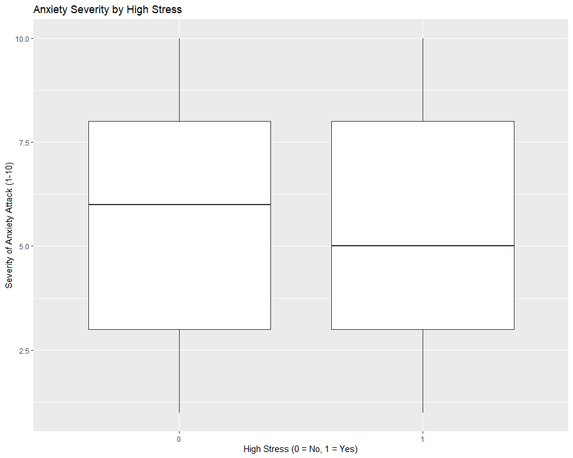

```r
# --- Visualizations ---

# --- Stress Level vs. Anxiety Severity (Boxplot) ---
plot_stress_severity <- ggplot(anxiety_data_processed, aes(x = factor(high_stress), y = severity_of_anxiety_attack_1_10)) +
  geom_boxplot() +
  labs(title = "Anxiety Severity by High Stress",
       x = "High Stress (0 = No, 1 = Yes)",
       y = "Severity of Anxiety Attack (1-10)")
print(plot_stress_severity)
```

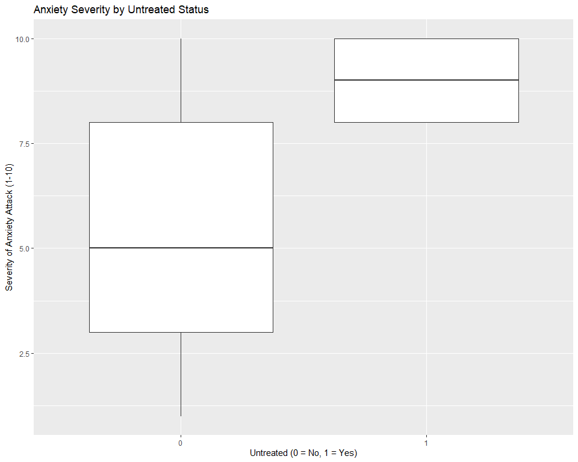

```r
# --- Untreated vs. Treated (Boxplot) ---
plot_untreated_severity <- ggplot(anxiety_data_processed, aes(x = factor(untreated), y = severity_of_anxiety_attack_1_10)) +
    geom_boxplot() +
    labs(title = "Anxiety Severity by Untreated Status",
         x = "Untreated (0 = No, 1 = Yes)",
         y = "Severity of Anxiety Attack (1-10)")
print(plot_untreated_severity)
```

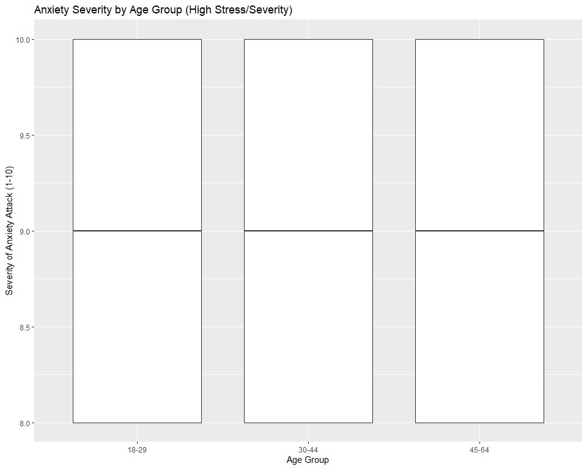

```r
# --- Lifestyle Factors vs. Anxiety Severity (Scatterplots) ---
lifestyle_vars <- c("sleep_hours", "physical_activity_hrs_week", "caffeine_intake_mg_day", "alcohol_consumption_drinks_week", "diet_quality_1_10")

lifestyle_plots <- lapply(lifestyle_vars, function(var) {
  plot_lifestyle_vs_severity(anxiety_data_processed, var)
})

# --- Age Groups vs. Anxiety Severity (within high-stress/high-severity) ---
plot_age_severity <- ggplot(anxiety_data_processed %>% filter(high_stress == 1, high_severity == 1), aes(x = age_group, y = severity_of_anxiety_attack_1_10)) +
  geom_boxplot() +
  labs(title = "Anxiety Severity by Age Group (High Stress/Severity)",
       x = "Age Group",
       y = "Severity of Anxiety Attack (1-10)")
print(plot_age_severity)
```

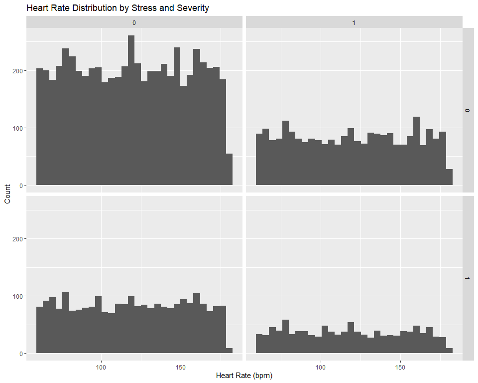

```r
# --- Histograms of Key Metrics, Faceted by high_stress and high_severity ---

# Heart Rate
plot_hr_facet <- ggplot(anxiety_data_processed, aes(x = heart_rate_bpm_during_attack)) +
  geom_histogram(bins = 30) +
  facet_grid(high_stress ~ high_severity) + # Facet by both
  labs(title = "Heart Rate Distribution by Stress and Severity",
       x = "Heart Rate (bpm)",
       y = "Count")
print(plot_hr_facet)
```

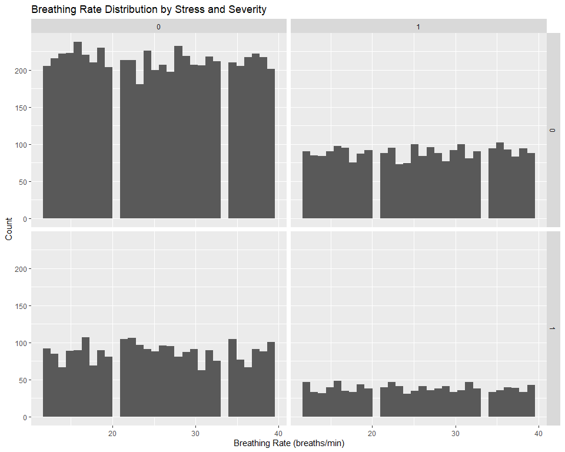

```r
# Breathing Rate
plot_br_facet <- ggplot(anxiety_data_processed, aes(x = breathing_rate_breaths_min)) +
  geom_histogram(bins = 30) +
  facet_grid(high_stress ~ high_severity) + # Facet by both
  labs(title = "Breathing Rate Distribution by Stress and Severity",
       x = "Breathing Rate (breaths/min)",
       y = "Count")
print(plot_br_facet)
```

```r
# --- Stacked Bar Plots for Categorical Variables (Question 6)---

categorical_vars_q6 <- c("smoking", "family_history_of_anxiety", "dizziness", "recent_major_life_event")

categorical_comparison_plots <- lapply(categorical_vars_q6, function(var){
    plot_categorical_comparison(anxiety_data_processed, var)
})
```

**Visualization Insights:**

These visualizations provide a visual exploration of the data and help us identify potential patterns and relationships to investigate further with statistical tests.

### 5.3. Correlation Analysis

```r
# --- Correlation Analysis ---

# Calculate correlations
correlations <- anxiety_data_processed %>%
  select(all_of(lifestyle_vars), severity_of_anxiety_attack_1_10) %>%
  cor(use = "pairwise.complete.obs")  # Handle potential missing values

print("Correlation Matrix:")
```

```
[1] "Correlation Matrix:"
```

```r
print(kable(correlations, format = "markdown", digits = 3))
```

|  | sleep_hours | physical_activity_hrs_week | caffeine_intake_mg_day | alcohol_consumption_drinks_week | diet_quality_1_10 | severity_of_anxiety_attack_1_10 |
| --- | --- | --- | --- | --- | --- | --- |
| sleep_hours | 1.000 | 0.004 | 0.005 | 0.022 | 0.005 | -0.003 |
| physical_activity_hrs_week | 0.004 | 1.000 | 0.002 | -0.003 | 0.002 | 0.018 |
| caffeine_intake_mg_day | 0.005 | 0.002 | 1.000 | -0.008 | 0.002 | 0.004 |
| alcohol_consumption_drinks_week | 0.022 | -0.003 | -0.008 | 1.000 | 0.018 | 0.009 |
| diet_quality_1_10 | 0.005 | 0.002 | 0.002 | 0.018 | 1.000 | -0.010 |
| severity_of_anxiety_attack_1_10 | -0.003 | 0.018 | 0.004 | 0.009 | -0.010 | 1.000 |

```r
# Perform correlation tests (for statistical significance)
correlation_tests <- lapply(lifestyle_vars, function(var) {
  cor.test(anxiety_data_processed[[var]], anxiety_data_processed$severity_of_anxiety_attack_1_10)
})
names(correlation_tests) <- lifestyle_vars # Name the list elements

print("Correlation Tests:")
```

```
[1] "Correlation Tests:"
```

```r
# Using capture.output to format the correlation test results
for (var in names(correlation_tests)) {
    cat(paste("\n*** Correlation Test for:", var, "***\n"))
    cat(capture.output(print(correlation_tests[[var]])), sep = "\n")
}
```

```
*** Correlation Test for: sleep_hours ***

    Pearson's product-moment correlation

data:  anxiety_data_processed[[var]] and anxiety_data_processed$severity_of_anxiety_attack_1_10
t = -0.36075, df = 11998, p-value = 0.7183
alternative hypothesis: true correlation is not equal to 0
95 percent confidence interval:
 -0.02118449  0.01459966
sample estimates:
         cor
-0.003293474


*** Correlation Test for: physical_activity_hrs_week ***

    Pearson's product-moment correlation

data:  anxiety_data_processed[[var]] and anxiety_data_processed$severity_of_anxiety_attack_1_10
t = 1.9733, df = 11998, p-value = 0.04848
alternative hypothesis: true correlation is not equal to 0
95 percent confidence interval:
 0.0001200085 0.0358929396
sample estimates:
       cor
0.01801224


*** Correlation Test for: caffeine_intake_mg_day ***

    Pearson's product-moment correlation

data:  anxiety_data_processed[[var]] and anxiety_data_processed$severity_of_anxiety_attack_1_10
t = 0.44071, df = 11998, p-value = 0.6594
alternative hypothesis: true correlation is not equal to 0
95 percent confidence interval:
 -0.01386988  0.02191408
sample estimates:
        cor
0.004023384
```

[output cut: 13 more lines]

```
0.009288498


*** Correlation Test for: diet_quality_1_10 ***

    Pearson's product-moment correlation

data:  anxiety_data_processed[[var]] and anxiety_data_processed$severity_of_anxiety_attack_1_10
t = -1.1162, df = 11998, p-value = 0.2644
alternative hypothesis: true correlation is not equal to 0
95 percent confidence interval:
 -0.028076716  0.007704107
sample estimates:
        cor
-0.01018957
```

**Correlation Analysis Findings:**

The correlation matrix and correlation tests reveal that, across the *entire* dataset, the linear relationships between the measured lifestyle factors and anxiety severity are generally *very weak*. Most correlations are close to zero, and most are not statistically significant (p > 0.05). The one exception is a very weak, *positive* correlation between `physical_activity_hrs_week` and `severity_of_anxiety_attack_1_10` (r = 0.018, p = 0.048). This is a small effect and could be spurious, but it’s worth noting.

**Implications:**

- These findings suggest that, *in this dataset*, these lifestyle factors, *on their own*, are not strong predictors of anxiety severity.
- This *doesn’t* mean these factors are unimportant, but it suggests that their relationship with anxiety might be more complex (e.g., non-linear, or mediated by other variables like stress).

### 5.4. Statistical Tests

```r
# --- Statistical Tests ---

# --- T-test: Heart Rate by High Severity ---
# Question 8
t_test_hr <- t.test(heart_rate_bpm_during_attack ~ high_severity, data = anxiety_data_processed)
print("T-test: Heart Rate by High Severity")
```

```
[1] "T-test: Heart Rate by High Severity"
```

```r
print(t_test_hr)
```

```
    Welch Two Sample t-test

data:  heart_rate_bpm_during_attack by high_severity
t = 0.35424, df = 6625.5, p-value = 0.7232
alternative hypothesis: true difference in means between group 0 and group 1 is not equal to 0
95 percent confidence interval:
 -1.122921  1.618274
sample estimates:
mean in group 0 mean in group 1
       119.4721        119.2244
```

```r
# Calculate Cohen's d (effect size) for t-test
cohens_d_hr <- (mean(anxiety_data_processed$heart_rate_bpm_during_attack[anxiety_data_processed$high_severity == 1], na.rm = TRUE) -
                 mean(anxiety_data_processed$heart_rate_bpm_during_attack[anxiety_data_processed$high_severity == 0], na.rm = TRUE)) /
                sd(anxiety_data_processed$heart_rate_bpm_during_attack, na.rm = TRUE)
cat(paste("\nCohen's d for Heart Rate t-test:", cohens_d_hr, "\n"))
```

```
Cohen's d for Heart Rate t-test: -0.00711577393072986
```

```r
# --- Chi-squared Tests and Cramer's V (Question 6 and others) ---
# Function to perform chi-squared test and calculate Cramer's V
chisq_and_cramersv <- function(var1, var2) {
  tbl <- table(var1, var2)
  chi2_result <- chisq.test(tbl, correct = FALSE) # No Yates' correction

  # Calculate Cramer's V
  chi2 <- chi2_result$statistic
  n <- sum(tbl)
  k <- min(nrow(tbl), ncol(tbl))
  cramers_v <- sqrt(chi2 / (n * (k - 1)))

  cat(paste("\nChi-squared test for", deparse(substitute(var1)), "and", deparse(substitute(var2)), ":\n"))
  print(chi2_result)
  cat(paste("Cramer's V:", cramers_v, "\n"))
}

# Apply to categorical variables vs. high_severity
for (var in categorical_vars_q6) {
  chisq_and_cramersv(anxiety_data_processed[[var]], anxiety_data_processed$high_severity)
}
```

```
Chi-squared test for anxiety_data_processed[[var]] and anxiety_data_processed$high_severity :

    Pearson's Chi-squared test

data:  tbl
X-squared = 1.6525, df = 1, p-value = 0.1986

Cramer's V: 0.0117350791293763

Chi-squared test for anxiety_data_processed[[var]] and anxiety_data_processed$high_severity :

    Pearson's Chi-squared test

data:  tbl
X-squared = 1.2796, df = 1, p-value = 0.258

Cramer's V: 0.0103263635366658

Chi-squared test for anxiety_data_processed[[var]] and anxiety_data_processed$high_severity :

    Pearson's Chi-squared test

data:  tbl
X-squared = 4.6197, df = 1, p-value = 0.03161

Cramer's V: 0.0196208553859889

Chi-squared test for anxiety_data_processed[[var]] and anxiety_data_processed$high_severity :

    Pearson's Chi-squared test

data:  tbl
X-squared = 0.96896, df = 1, p-value = 0.3249

Cramer's V: 0.00898590441984628
```

```r
# --- ANOVA and Post-Hoc Tests (for multiple group comparisons) ---

# Example: ANOVA for severity_of_anxiety_attack_1_10 by occupation
cat("\nANOVA: Anxiety Severity by Occupation:\n")
```

```
ANOVA: Anxiety Severity by Occupation:
```

```r
anova_occupation <- aov(severity_of_anxiety_attack_1_10 ~ occupation, data = anxiety_data_processed)
print(summary(anova_occupation))
```

```
               Df Sum Sq Mean Sq F value Pr(>F)
occupation      5     43   8.562   1.048  0.387
Residuals   11994  98012   8.172
```

```r
# Post-hoc test (Tukey's HSD) if ANOVA is significant
if (summary(anova_occupation)[[1]][["Pr(>F)"]][1] < 0.05) {
  cat("\nTukey's HSD Post-Hoc Test:\n")
  print(TukeyHSD(anova_occupation))
}


# Example: ANOVA for severity_of_anxiety_attack_1_10 by age_group
cat("\nANOVA: Anxiety Severity by Age Group:\n")
```

```
ANOVA: Anxiety Severity by Age Group:
```

```r
anova_age <- aov(severity_of_anxiety_attack_1_10 ~ age_group, data = anxiety_data_processed)
print(summary(anova_age))
```

```
               Df Sum Sq Mean Sq F value Pr(>F)
age_group       2     30  15.112    1.85  0.157
Residuals   11997  98025   8.171
```

```r
if (summary(anova_age)[[1]][["Pr(>F)"]][1] < 0.05) {
  cat("\nTukey's HSD Post-Hoc Test:\n")
  print(TukeyHSD(anova_age))
}
```

**Statistical Test Findings:**

**Implications:**

- The t-test and Cohen’s d results suggest that heart rate, at least as measured in this dataset, is not a strong differentiator between high and low anxiety severity groups.
- The chi-squared tests indicate that, *with the exception of dizziness*, the categorical variables we examined are not strongly associated with high anxiety severity. The association with *dizziness*, while statistically significant, is very weak in terms of effect size.
- The ANOVA results support our earlier decision to shift focus away from occupation as a primary segmentation variable.
- The ANOVA also indicates that the different age groups do not present significant differences.

## 6. Analysis Summary and Findings

This section summarizes the key findings from the Analyze phase, directly addressing the SMART questions and providing insights relevant to targeting the “Calm Button” application. We’ll present each question, followed by a concise conclusion and the supporting evidence from our analysis.

### Key Findings:

**Question 1 (Stress & Severity):** Among individuals reporting high stress levels (stress_level_1_10 >= 8), what is the distribution of `severity_of_anxiety_attack_1_10`? What percentage report severe anxiety attacks (>= 8)?

- **Conclusion:** A substantial portion of the sample reports high stress, and within that group, a significant percentage also experiences high anxiety severity.
- **Evidence:** Nearly 30% reported high stress (8+). Within the high-stress group, 30.4% also reported high anxiety severity (8+). (See `descriptive-stats` chunk and `high_stress_skim` table).

**Question 2 (Lifestyle & High Stress/Severity):** Within the high-stress, high-severity group, what are the average values and distributions of key lifestyle factors, and how do they compare to the overall dataset averages?

**Question 3 (Untreated Need):** What proportion of individuals with high stress and high anxiety severity report no therapy and no medication use?

- **Conclusion:** A small but potentially significant 6.4% of the high-stress/high-severity group is “untreated” (no therapy or medication).
- **Evidence:** Direct calculation using the `untreated` indicator variable (`analyze-enhancements` chunk).

**Question 4 (Age & High Stress/Severity):** Within the high-stress, high-severity group, are there significant differences in anxiety severity, lifestyle factors, or treatment usage across different age groups?

**Question 5 (Lifestyle Correlations):** Across the entire dataset, what are the correlations between the key lifestyle factors and `severity_of_anxiety_attack_1_10`? Are these correlations statistically significant?

- **Conclusion:** Correlations between lifestyle factors and anxiety severity were very weak and mostly non-significant across the entire dataset.
- **Evidence:** Correlation matrix and correlation tests (`correlation-analysis` chunk). Most p-values were > 0.05, and correlation coefficients were close to zero.

**Question 6 (Smoking, Family History, Dizziness, Life Events):** What proportion of individuals with high anxiety severity report these factors, compared to those with low severity?

- **Conclusion:** Only dizziness showed a statistically significant (though weak) association with high anxiety severity. The other factors did not.
- **Evidence:** Chi-squared tests and Cramer’s V calculations (`statistical-tests` and `analyze-enhancements` chunks). Dizziness: p = 0.03161, Cramer’s V = 0.020. All other factors: p > 0.05.

**Question 9 (Therapy Usage and Severity):** Among those who report attending therapy, what is the median `severity_of_anxiety_attack_1_10`?

- **Conclusion** The median anxiety score for those that attend therapy is: 6.
- **Evidence:** Direct calculation of the median (`descriptive-stats` chunk).

### Overall Key Findings and Implications:

- **Untreated Segment:** The “untreated” group (high stress, high severity, no therapy/medication) represents a potentially valuable niche market for the Calm Button.
- **Lifestyle Factors:** Lifestyle factors, *in isolation*, are not strong predictors of anxiety severity in this dataset.
- **Dizziness:** Dizziness during anxiety attacks may be a useful indicator for identifying individuals with high anxiety severity.

### Limitations:

- **Self-Reported Data:** Data is based on self-reported measures.
- **Cross-Sectional Data:** Data represents a single point in time.
- **Even Occupational Distribution:** Limits conclusions about specific professions.
- **No Direct Workplace Measures:** Limits analysis of workplace-specific stressors.